# CRIM 595 Temporal Project

### Hotspots and Coldspots by the Hours of the Day

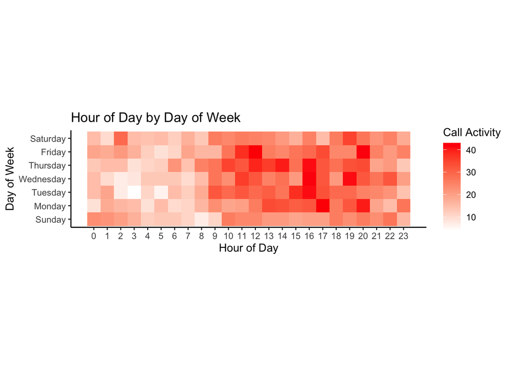

```r
graph <- ggplot(calls.day.time, aes(hour, dow, fill = count)) +
  geom_tile(color = "black", lwd = .5, linetype = 1) +
  geom_text(aes(label = count), color = "black", size = 2.5) +
  scale_fill_gradient(low = "white", high = "red") +
  theme(legend.position = "none") +
  coord_fixed()

graph1 <- ggplot(calls.day.time, aes(hour, dow, fill = count)) +
  geom_tile() +
  scale_fill_gradient(low = "white", high = "red") +
  guides(fill = guide_colourbar(title = "Call Activity")) +
  theme_classic() +
  coord_fixed()

graph1 +
  labs(x = "Hour of Day", y = "Day of Week", title = "Hour of Day by Day of Week") +
  scale_y_discrete(limits = c("Sunday", "Monday", "Tuesday", "Wednesday", "Thursday", "Friday", "Saturday")) +
  scale_x_continuous(breaks = c(0:23))
```

To my surprise, 911 hang up call hour of day hotspots are not in the early morning hours at and past midnight but rather between 11am-8pm. 4pm appears to be the prime time for 911 hang up calls to occur as can be noticed in the graph displayed above, with Tuesday-Thursday as the hottest days. Revealing 4pm Tuesdays-Thursdays to be the prime for 911 hang up calls to occur. The coldest of hour of day cold spots are likewise lumped together between 11pm-7am. 4am is the coldest spot with (82) calls total, followed by 5am with (83) calls and 3am with (85) calls. The reoccurring pattern that is likely to continue is for these 911 hang up calls to mostly occur during broad daylight and predominately between 12pm-4pm. With 16 years worth of data reflecting these calls to most heavily occur during the earlier afternoon, it is very likely that there will not be a major influx of 912 hang up calls at the later evening and early morning hours between 11pm-8am.

### Concluding Thoughts

```r
calls.year.month.day <- calls %>%
  group_by(year, month, day) %>%
  summarise(count = n())
```

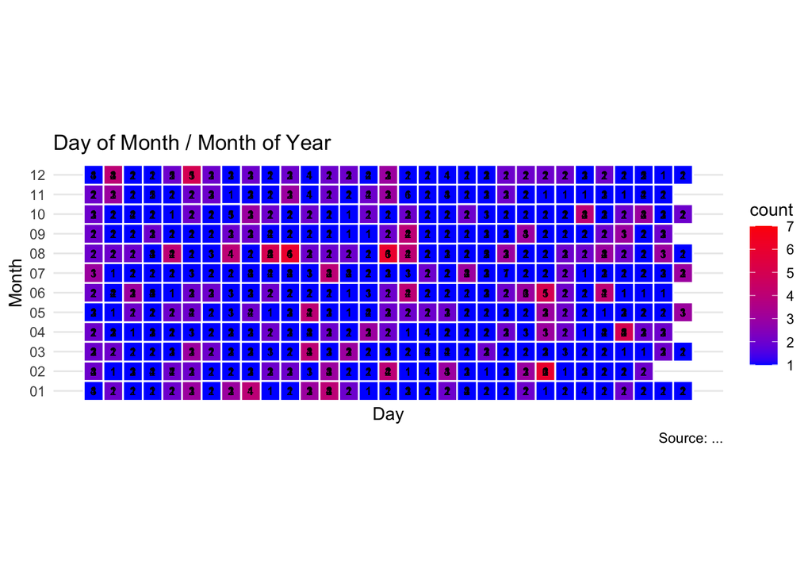

```r
calls.year.month.day <- subset(calls.year.month.day, !is.na(calls.year.month.day$day))

graph3 <- ggplot(calls.year.month.day, aes(day, month, fill = count)) +
  geom_tile(color = "white", lwd = .5, linetype = 1) +
  geom_text(aes(label = count), color = "black", size = 2.5) +
  scale_fill_gradient(low = "blue", high = "red") +
  theme(legend.position = "none") +
  coord_fixed()

graph3 + labs(x = "Day", y = "Month", title = "Day of Month / Month of Year", caption = "Source: ...") +
  scale_x_continuous(breaks = c(01-12)) +
  theme_minimal()
```

With 911 hang up calls being capable of occurring for a handful of reasons, I believe that hot spots and cold spots are likely to change across and over time for this specific call for service. One thing that was quite consistent, or clear, throughout all these visuals was August being a prime hot spot month, Tuesday-Thursday being the hottest days, and 12pm-5pm being the hottest hours. Another consistent finding was Saturday and Sundays being cold spot days, 12am-7am being cold spot times, and November and January being the coldest of the 12 months. The four months of 2023 data captured in this analysis help to make the presumption that hotspots and cold spots are changing over time for 911 hang up calls. 911 hang up calls were not such a phenomenon until 2020. Since 2020 hot spots have started to quickly emerge and will likely continue to remain or increase this coming year if the rest of the 8 months not captured in this years data are in line with the 4 that have been captured.